# Pratical Machine Learning

cuissai

Monday, May 11, 2015

Six subjects were asked to perform one set of 10 repetitions of the Unilateral Dumbbell Biceps Curl in five different fashions: five classes A B C D E (Class A) exactly according to the specification (Class B) throwing the elbows to the front (Class C) lifting the dumbbell only halfway (Class D) lowering the dumbbell only halfway (Class E) throwing the hips to the front For the six subjects the data are collected with the accelerometers on the belt, forearm, arm and dumbell. Can we predict in which fashion the movement are performed.

```r
#downloading
#reading the dataset
training <- read.csv(url("http://d396qusza40orc.cloudfront.net/predmachlearn/pml-training.csv"),na.strings=c("NA","#DIV/0!",""))
testingSample <- read.csv(url("http://d396qusza40orc.cloudfront.net/predmachlearn/pml-testing.csv"),na.strings=c("NA","#DIV/0!",""))
```

## Exploratory analysis

The training dataset contains 19622 observations to make a model and the test / validation dataset has only 20 observations for the test assignement. We have 160 potential explicatives variables The six participants have homogeneous data and approx similar number of data rows. There are variables in the data set a time series, but the time effect is not very strong. We have a good separation of classes

```r
#names(training)
table(training$user_name)
```

```
##
##   adelmo carlitos  charles   eurico   jeremy    pedro
##     3892     3112     3536     3070     3402     2610
```

```r
table(training$classe ,training$user_name)
```

```
##
##     adelmo carlitos charles eurico jeremy pedro
##   A   1165      834     899    865   1177   640
##   B    776      690     745    592    489   505
##   C    750      493     539    489    652   499
##   D    515      486     642    582    522   469
##   E    686      609     711    542    562   497
```

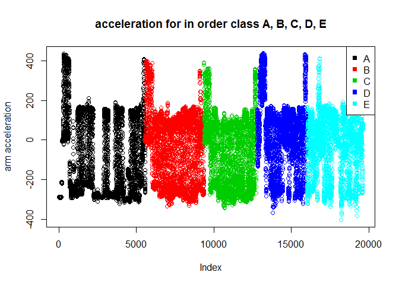

[figure not shown]

```r
#str(training$classe)
#table(training$cvtd_timestamp, training$user_name)
#length(unique(training$cvtd_timestamp))
plot(training$accel_arm_x, col=training$classe, ylab="arm acceleration",main="acceleration for in order class A, B, C, D, E")
legend("topright", col=1:5, legend=LETTERS[1:5], pch=15)
```

## Preprocessing

we applied function nearZeroVar to reduce the number of predictors. The variables with a small variance that got the value TRUE are removed, and variables with a high amount of missing values are deleted.  
The participants worked the exercises in time, but that is not the right information for predicting the type of activity therefor all the variables ‘time’ were removed.

```r
nsv <- nearZeroVar(training, saveMetrics=TRUE)
head(nsv, 10)
```

```
##                      freqRatio percentUnique zeroVar   nzv
## X                     1.000000  100.00000000   FALSE FALSE
## user_name             1.100679    0.03057792   FALSE FALSE
## raw_timestamp_part_1  1.000000    4.26562022   FALSE FALSE
## raw_timestamp_part_2  1.000000   85.53154622   FALSE FALSE
## cvtd_timestamp        1.000668    0.10192641   FALSE FALSE
## new_window           47.330049    0.01019264   FALSE  TRUE
## num_window            1.000000    4.37264295   FALSE FALSE
## roll_belt             1.101904    6.77810621   FALSE FALSE
## pitch_belt            1.036082    9.37722964   FALSE FALSE
## yaw_belt              1.058480    9.97349913   FALSE FALSE
```

```r
# remove variables with near zero variance
newnames <- rownames(nsv)[!nsv$nzv]
training <- training[, newnames]
# remove variables with more than 90% missing values
missvars <- apply(training, 2, function(x) sum(is.na(x))/length(x))
w <- which(missvars > .9);
newnames <- names(missvars[-w])
 # remove time variables
newnames <- newnames[-c(1:6)]
training <- training[, newnames]
names(training)
```

```
##  [1] "roll_belt"            "pitch_belt"           "yaw_belt"
##  [4] "total_accel_belt"     "gyros_belt_x"         "gyros_belt_y"
##  [7] "gyros_belt_z"         "accel_belt_x"         "accel_belt_y"
## [10] "accel_belt_z"         "magnet_belt_x"        "magnet_belt_y"
## [13] "magnet_belt_z"        "roll_arm"             "pitch_arm"
## [16] "yaw_arm"              "total_accel_arm"      "gyros_arm_x"
## [19] "gyros_arm_y"          "gyros_arm_z"          "accel_arm_x"
## [22] "accel_arm_y"          "accel_arm_z"          "magnet_arm_x"
## [25] "magnet_arm_y"         "magnet_arm_z"         "roll_dumbbell"
## [28] "pitch_dumbbell"       "yaw_dumbbell"         "total_accel_dumbbell"
## [31] "gyros_dumbbell_x"     "gyros_dumbbell_y"     "gyros_dumbbell_z"
## [34] "accel_dumbbell_x"     "accel_dumbbell_y"     "accel_dumbbell_z"
## [37] "magnet_dumbbell_x"    "magnet_dumbbell_y"    "magnet_dumbbell_z"
## [40] "roll_forearm"         "pitch_forearm"        "yaw_forearm"
## [43] "total_accel_forearm"  "gyros_forearm_x"      "gyros_forearm_y"
## [46] "gyros_forearm_z"      "accel_forearm_x"      "accel_forearm_y"
## [49] "accel_forearm_z"      "magnet_forearm_x"     "magnet_forearm_y"
## [52] "magnet_forearm_z"     "classe"
```

```r
library(caret)
set.seed(44944)
ParTraining <- createDataPartition(y=training$classe, p=0.7, list=FALSE)
trainingSet <- training[ParTraining, ]
testingSet <- training[-ParTraining,]
dim(trainingSet); dim(testingSet)
```

```
## [1] 13737    53
```

```
## [1] 5885   53
```

## Feature selection

```r
library(randomForest)
inSelect <- sample(1:nrow(trainingSet), 1000, replace=FALSE)
modfit <-  train(y=trainingSet$classe[inSelect], x=trainingSet[inSelect, -53],   trControl=trainControl(method="cv", number=3, repeats=2), tuneLength = 1)
best <- varImp(modfit)
tab <- best$importance;    or <-order(tab$Overall, decreasing = TRUE)
tab$names <- rownames(tab)
tab <- tab[or,]
varnames <- tab$names[1:25] # first best 25 predictors
varnames
```

```
##  [1] "roll_belt"            "pitch_forearm"        "magnet_dumbbell_z"
##  [4] "yaw_belt"             "magnet_dumbbell_y"    "roll_dumbbell"
##  [7] "roll_forearm"         "magnet_dumbbell_x"    "pitch_belt"
## [10] "magnet_belt_y"        "accel_dumbbell_y"     "accel_belt_z"
## [13] "accel_forearm_x"      "magnet_belt_z"        "accel_dumbbell_x"
## [16] "yaw_dumbbell"         "accel_dumbbell_z"     "magnet_forearm_z"
## [19] "accel_arm_x"          "magnet_forearm_x"     "total_accel_dumbbell"
## [22] "magnet_arm_z"         "gyros_dumbbell_y"     "gyros_belt_z"
## [25] "pitch_dumbbell"
```

Some variables are correlated, like (magnet_belt_y) and (magnet_belt_z). coefficient 0.8. In following figure can we see, only one of this two variables would suffice.

```r
cor(trainingSet$magnet_belt_y, trainingSet$magnet_belt_z)
```

```
## [1] 0.7755565
```

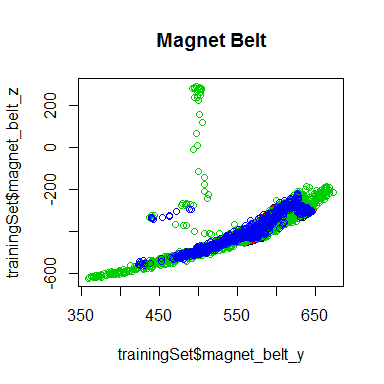

```r
plot(trainingSet$magnet_belt_y, trainingSet$magnet_belt_z, col=training$classe, main="Magnet Belt")
```

## model building

```r
modfit <-  train(y=trainingSet$classe, x=trainingSet[, varnames],   trControl=trainControl(method="cv", number=3, repeats=2), tuneLength = 1)
modfit
```

```
## Random Forest
##
## 13737 samples
##    25 predictor
##     5 classes: 'A', 'B', 'C', 'D', 'E'
##
## No pre-processing
## Resampling: Cross-Validated (3 fold)
##
## Summary of sample sizes: 9157, 9160, 9157
##
## Resampling results
##
##   Accuracy   Kappa      Accuracy SD  Kappa SD
##   0.9863878  0.9827803  0.003281527  0.004150681
##
## Tuning parameter 'mtry' was held constant at a value of 8
##
```

```r
pr <- predict(modfit, newdata=testingSet[,varnames])
confusionMatrix(table(pr, testingSet$classe))
```

```
## Confusion Matrix and Statistics
##
##
## pr     A    B    C    D    E
##   A 1674   12    0    0    0
##   B    0 1121   10    0    0
##   C    0    6 1014    9    8
##   D    0    0    2  955    1
##   E    0    0    0    0 1073
##
## Overall Statistics
##
##                Accuracy : 0.9918
##                  95% CI : (0.9892, 0.994)
##     No Information Rate : 0.2845
##     P-Value [Acc > NIR] : < 2.2e-16
##
##                   Kappa : 0.9897
##  Mcnemar's Test P-Value : NA
##
## Statistics by Class:
##
##                      Class: A Class: B Class: C Class: D Class: E
## Sensitivity            1.0000   0.9842   0.9883   0.9907   0.9917
## Specificity            0.9972   0.9979   0.9953   0.9994   1.0000
## Pos Pred Value         0.9929   0.9912   0.9778   0.9969   1.0000
## Neg Pred Value         1.0000   0.9962   0.9975   0.9982   0.9981
## Prevalence             0.2845   0.1935   0.1743   0.1638   0.1839
## Detection Rate         0.2845   0.1905   0.1723   0.1623   0.1823
## Detection Prevalence   0.2865   0.1922   0.1762   0.1628   0.1823
## Balanced Accuracy      0.9986   0.9910   0.9918   0.9950   0.9958
```

## prediction on test sample data set

```
##    problem_id predTest
## 1           1        B
## 2           2        A
## 3           3        B
## 4           4        A
## 5           5        A
## 6           6        E
## 7           7        D
## 8           8        B
## 9           9        A
## 10         10        A
## 11         11        B
## 12         12        C
## 13         13        B
## 14         14        A
## 15         15        E
## 16         16        E
## 17         17        A
## 18         18        B
## 19         19        B
## 20         20        B
```